# Classification

## Iris Data Set ( 鳶尾花資料 )

- iris 資料變數說明
  - Sepal: 花萼
  - Petal: 花瓣
- 只取出 virginica 和 versicolor 的資料
- 目的: 建立分類模型分辨 virginica 和 versicolor

```r
# 只取出 virginica 和 versicolor
iris.small <- iris[iris$Species %in% c("versicolor","virginica"),]
iris.small$Species=factor(iris.small$Species,level=c("versicolor","virginica"))

# iris.small 前 5 筆資料
head(iris.small)

# iris.small 的 columns name
names(iris.small)

# iris.small 資料維度
dim(iris.small)
```

|  | Sepal.Length | Sepal.Width | Petal.Length | Petal.Width | Species |
| --- | --- | --- | --- | --- | --- |
| 51 | 7.0 | 3.2 | 4.7 | 1.4 | versicolor |
| 52 | 6.4 | 3.2 | 4.5 | 1.5 | versicolor |
| 53 | 6.9 | 3.1 | 4.9 | 1.5 | versicolor |
| 54 | 5.5 | 2.3 | 4.0 | 1.3 | versicolor |
| 55 | 6.5 | 2.8 | 4.6 | 1.5 | versicolor |
| 56 | 5.7 | 2.8 | 4.5 | 1.3 | versicolor |

1. 'Sepal.Length'

2. 'Sepal.Width'

3. 'Petal.Length'

4. 'Petal.Width'

5. 'Species'

1. 100

2. 5

變數與品種的關係

- 藍色圓形: versicolor
- 紅色三角形: virginica

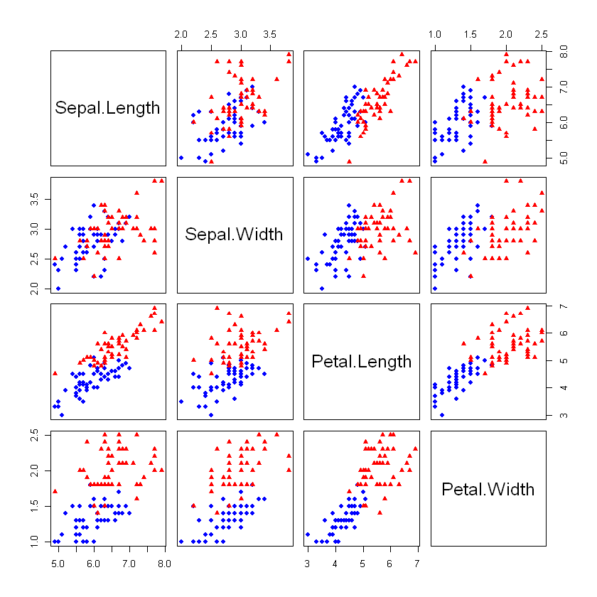

```r
color_list=c("blue","red")
pairs(iris.small[,-5],col=color_list[iris.small$Species],pch=c(16,17)[iris.small$Species])
```

## Logistic Regression

- glm 指令配適 Logistic Regression
- summary 將模型的結果印出

```r
glm.fit=glm(Species~Sepal.Length+Sepal.Width+Petal.Length+Petal.Width,
            data=iris.small ,family =binomial)
summary(glm.fit)
```

```
Call:
glm(formula = Species ~ Sepal.Length + Sepal.Width + Petal.Length +
    Petal.Width, family = binomial, data = iris.small)

Deviance Residuals:
     Min        1Q    Median        3Q       Max
-2.01105  -0.00541  -0.00001   0.00677   1.78065

Coefficients:
             Estimate Std. Error z value Pr(>|z|)
(Intercept)   -42.638     25.707  -1.659   0.0972 .
Sepal.Length   -2.465      2.394  -1.030   0.3032
Sepal.Width    -6.681      4.480  -1.491   0.1359
Petal.Length    9.429      4.737   1.991   0.0465 *
Petal.Width    18.286      9.743   1.877   0.0605 .
---
Signif. codes:  0 '***' 0.001 '**' 0.01 '*' 0.05 '.' 0.1 ' ' 1

(Dispersion parameter for binomial family taken to be 1)

    Null deviance: 138.629  on 99  degrees of freedom
Residual deviance:  11.899  on 95  degrees of freedom
AIC: 21.899

Number of Fisher Scoring iterations: 10
```

glm 配適模型如下

- predict 對模型進行預測觀測值是 virginica 的機率 ( type="response" )
- glm 預測值為 factor 為 1 的機率
- contrasts 能確定 factor 變數的 levels
- 使用 0.5 進行切分預測是否為 virginica
- 得出混淆矩陣( confusion matrix )和模型精確度 ( accuracy )

```r
contrasts(iris.small$Species)
glm.probs= predict(glm.fit ,type ="response")
glm.pred=rep("versicolor",100)
glm.pred[glm.probs>=0.5]="virginica"
table(iris.small$Species,glm.pred)
mean(iris.small$Species==glm.pred)
```

|  | virginica |
| --- | --- |
| versicolor | 0 |
| virginica | 1 |

```
            glm.pred
             versicolor virginica
  versicolor         49         1
  virginica           1        49
```

0.98

```r
library(RColorBrewer)
cut_size=5
#col_list=brewer.pal(n = cut_size, name = 'RdYlBu')
col_list=colorpanel(cut_size, "Blue", "Red")
cut_quant=quantile(glm.probs,seq(0,1,length.out = cut_size+1))
pairs(iris.small[,-5],col=col_list[cut(glm.probs,breaks =cut_quant)],pch=c(16,17)[iris.small$Species])
```

[output not shown]

## Linear Discriminant Analysis

配適 LDA 模型

```r
library (MASS)
lda.fit=lda(Species~Sepal.Length+Sepal.Width+Petal.Length+Petal.Width,data=iris.small)
lda.fit
```

```
Call:
lda(Species ~ Sepal.Length + Sepal.Width + Petal.Length + Petal.Width,
    data = iris.small)

Prior probabilities of groups:
versicolor  virginica
       0.5        0.5

Group means:
           Sepal.Length Sepal.Width Petal.Length Petal.Width
versicolor        5.936       2.770        4.260       1.326
virginica         6.588       2.974        5.552       2.026

Coefficients of linear discriminants:
                    LD1
Sepal.Length -0.9431178
Sepal.Width  -1.4794287
Petal.Length  1.8484510
Petal.Width   3.2847304
```

- LDA 模型預測值變數中 class 為分類預測 ( 0.5 做切分點) 和 posterior 為機率值預測
- 得出混淆矩陣和模型精確度

```r
lda.pred=predict(lda.fit , iris.small)
table(iris.small$Species,lda.pred$class)
mean(iris.small$Species==lda.pred$class)
```

```
             versicolor virginica
  versicolor         48         2
  virginica           1        49
```

0.97

## Quadratic Discriminant Analysis

配適 QDA 模型

```r
library (MASS)
qda.fit=qda(Species~Sepal.Length+Sepal.Width+Petal.Length+Petal.Width,data=iris.small)
qda.fit
```

```
Call:
qda(Species ~ Sepal.Length + Sepal.Width + Petal.Length + Petal.Width,
    data = iris.small)

Prior probabilities of groups:
versicolor  virginica
       0.5        0.5

Group means:
           Sepal.Length Sepal.Width Petal.Length Petal.Width
versicolor        5.936       2.770        4.260       1.326
virginica         6.588       2.974        5.552       2.026
```

- 與 LDA 解釋相同
- 得出混淆矩陣和模型精確度

```r
qda.pred=predict(qda.fit , iris.small)
table(iris.small$Species,qda.pred$class)
mean(iris.small$Species==qda.pred$class)
```

```
             versicolor virginica
  versicolor         48         2
  virginica           1        49
```

0.97

## K-Nearest Neighbors (KNN)

- KNN 模型牽涉觀測值之間的距離
- 配適 KNN 前需先考慮各變數尺度是否需要調整一致
- 若其中一個變數尺度較大，則會被 KNN 認為其為分類中更重要的變數
- scale 將變數進行以下處理 $$\frac{X-mean(X)}{sd(X)}$$
- scale 後變數的圖如下

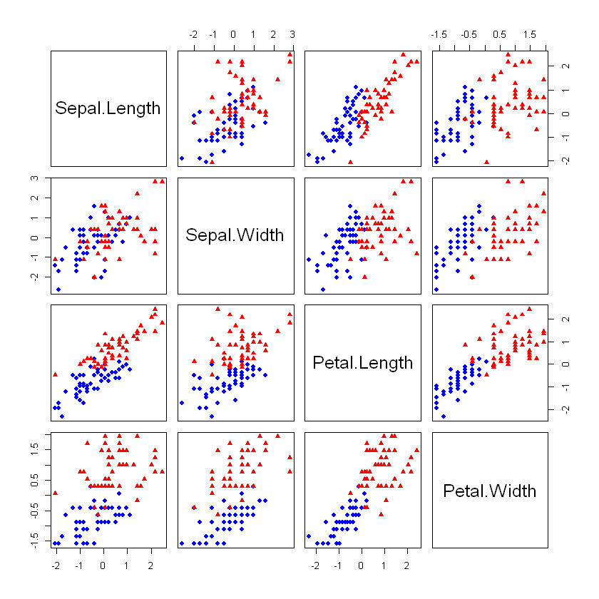

```r
library(class)
train.X=scale(iris.small[,-5])
pairs(train.X,col=color_list[iris.small$Species],pch=c(16,17)[iris.small$Species])
```

- 配適當 k=1 的 KNN 模型
- 得出混淆矩陣和模型精確度

```r
Species=iris.small$Species
knn.pred=knn (train.X,train.X,Species ,k=1)
table(knn.pred,Species)
mean(knn.pred==Species)
```

```
            Species
knn.pred     versicolor virginica
  versicolor         50         0
  virginica           0        50
```

1

- 配適當 k=3 的 KNN 模型
- 得出混淆矩陣和模型精確度

```r
knn.pred=knn (train.X,train.X,Species ,k=3)
table(knn.pred,Species)
mean(knn.pred==Species)
```

```
            Species
knn.pred     versicolor virginica
  versicolor         48         3
  virginica           2        47
```

0.95

## SVM

- 配適 SVM 模型

```r
library(e1071)
svmfit =svm(Species~., data=iris.small , kernel ="linear", cost =10,gamma=0.25)
summary(svmfit)
svm.pred=predict(svmfit ,iris.small )
table(iris.small$Species,svm.pred)
mean(iris.small$Species==svm.pred)
```

```
Call:
svm(formula = Species ~ ., data = iris.small, kernel = "linear",
    cost = 10, gamma = 0.25)


Parameters:
   SVM-Type:  C-classification
 SVM-Kernel:  linear
       cost:  10
      gamma:  0.25

Number of Support Vectors:  11

 ( 5 6 )


Number of Classes:  2

Levels:
 versicolor virginica
```

```
            svm.pred
             versicolor virginica
  versicolor         48         2
  virginica           1        49
```

0.97

```r
svmfit =svm(Species~., data=iris.small , kernel ="radial", cost =10,gamma=0.25)
summary(svmfit)
svm.pred=predict(svmfit ,iris.small )
table(iris.small$Species,svm.pred)
mean(iris.small$Species==svm.pred)
```

```
Call:
svm(formula = Species ~ ., data = iris.small, kernel = "radial",
    cost = 10, gamma = 0.25)


Parameters:
   SVM-Type:  C-classification
 SVM-Kernel:  radial
       cost:  10
      gamma:  0.25

Number of Support Vectors:  25

 ( 11 14 )


Number of Classes:  2

Levels:
 versicolor virginica
```

```
            svm.pred
             versicolor virginica
  versicolor         48         2
  virginica           0        50
```

0.98